# Red Wine Quality Exploration by Tao Zhou

Check scatter plot of quality VS density and the boxplot of density.

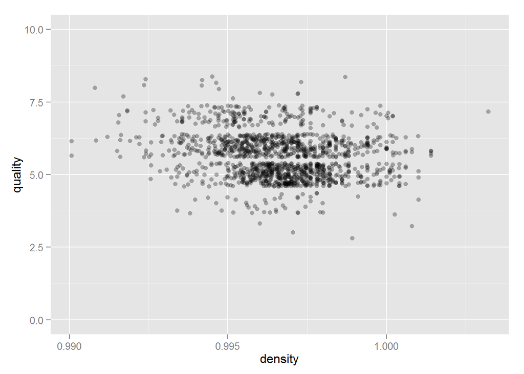

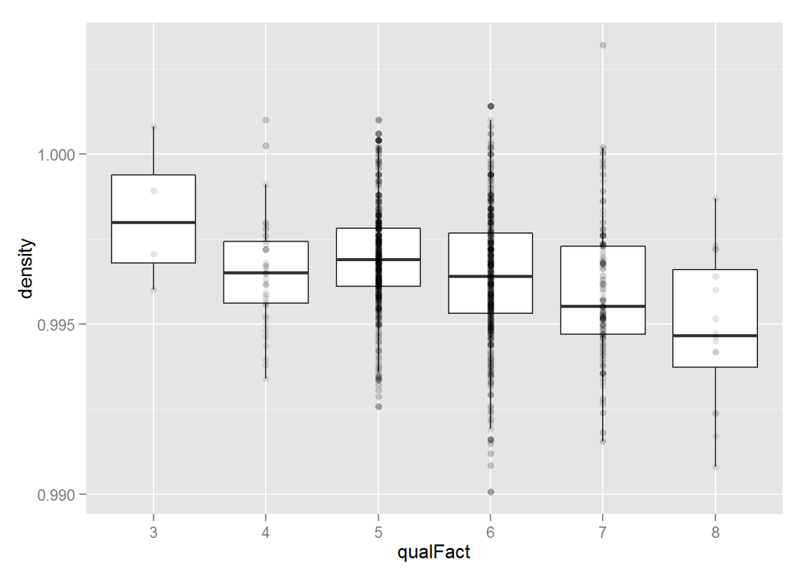

Most points are focusing in the area with density between 0.995 and 0.9975, and quality 5 and 6. The correltion is not very clear. This boxplot shows correlation more obvious than the scatter plot of quality VS density. The trends of median and average both show that when density decreases, quality increases.

Check scatter plot of quality VS sulphates and the boxplot of sulphates.

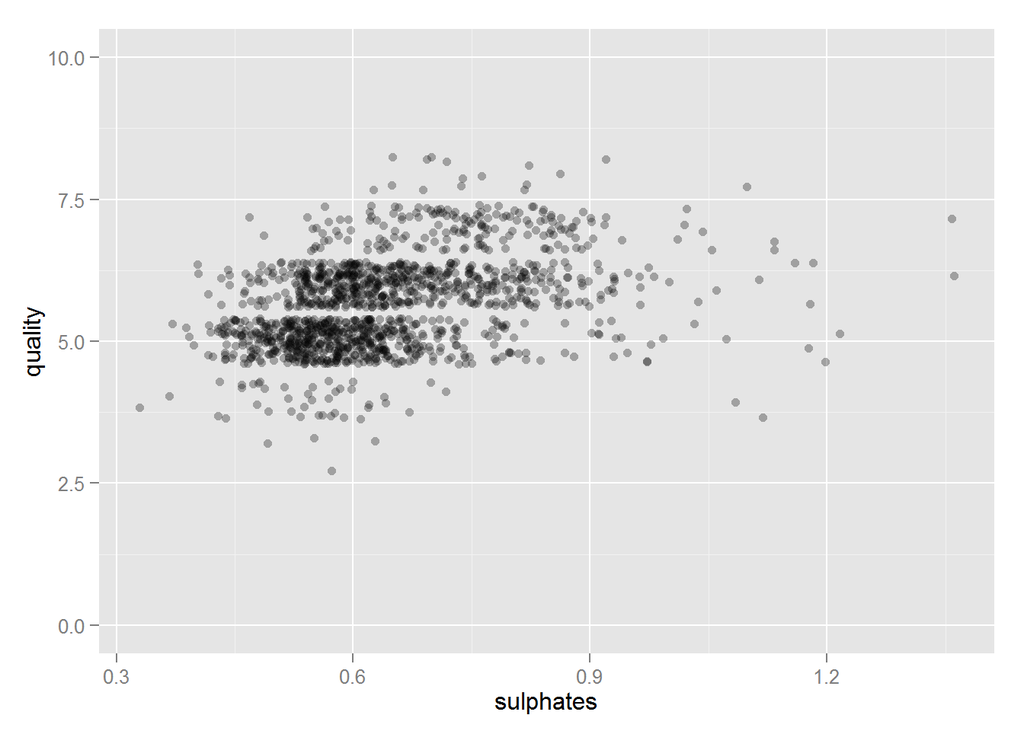

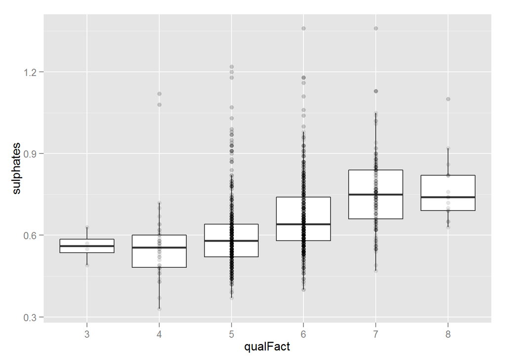

The scatter plot shows that when sulphates increases, quality also increases. The trend of mdeian and average in boxplot also shows that.

Check scatter plot of quality VS alcohol and the boxplot of alcohol.

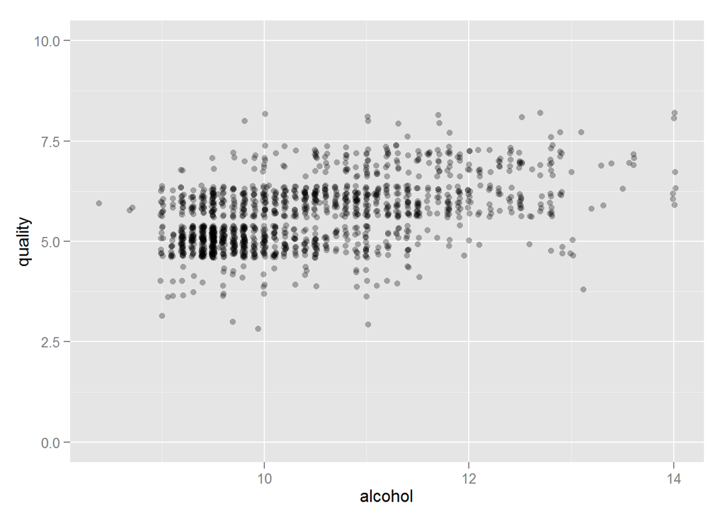

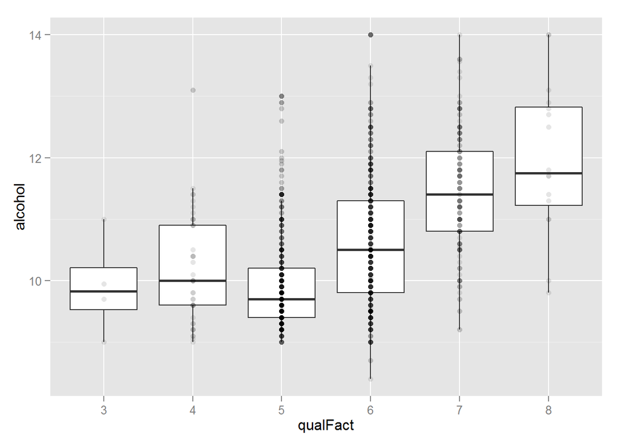

The scatter plot shows pretty clearly that when alcohol increases, quality increases. The median and average in the boxplot is also very clear on this point, although there is an exception at quality 5.

One thing I notice is that compared to scatter plot, boxplot has an advantage. It can reduce noises from outliers and show more clear relationship between two variables.

There is strong correlation between pH and fixed acidity from the corrlation table. I would like to draw a scatter plot to show that.

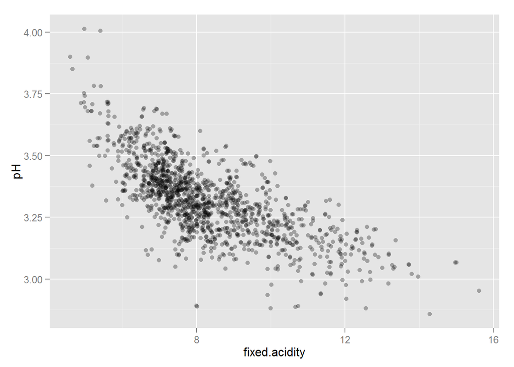

When fixed acidity increases, pH decreases.

And there is strong correlation between fixed acidity and density.

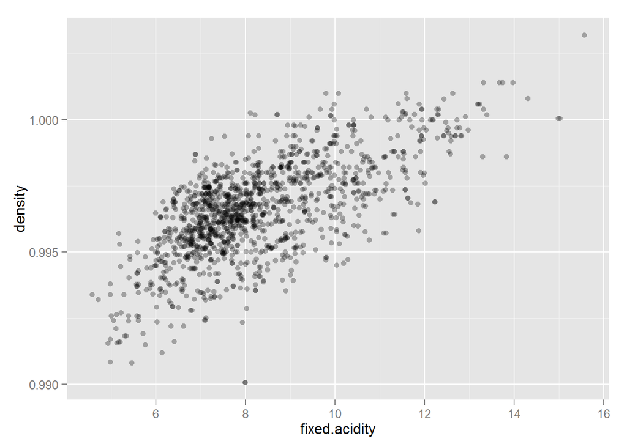

This is interesting. As I mentioned before, my guess is that components producing fixed acidity in red wine tend to have higher density than other components in red wine.

# Bivariate Analysis

### Did you observe any interesting relationships between the other features (not the main feature(s) of interest)?

Yes. I explored the correlation between fixed acidity and pH. They have strong negative correlation. I also explored the correlation between fixed acidity and density. Red wine with higher fixed acidity tends to have higher density.

### What was the strongest relationship you found?

From the calculation of correlation, the strongest correlation is between fixed acidity and pH.

# Multivariate Plots Section

From the bivariate analysis above, I know that alcohol is the most important feature affecting quality. I want to draw a scattering plot of alcohol and quality, with points colored by other features. To make the trend more clear, I’m going to continously use “geom_jitter”.

Plot using volatile acidity as color.

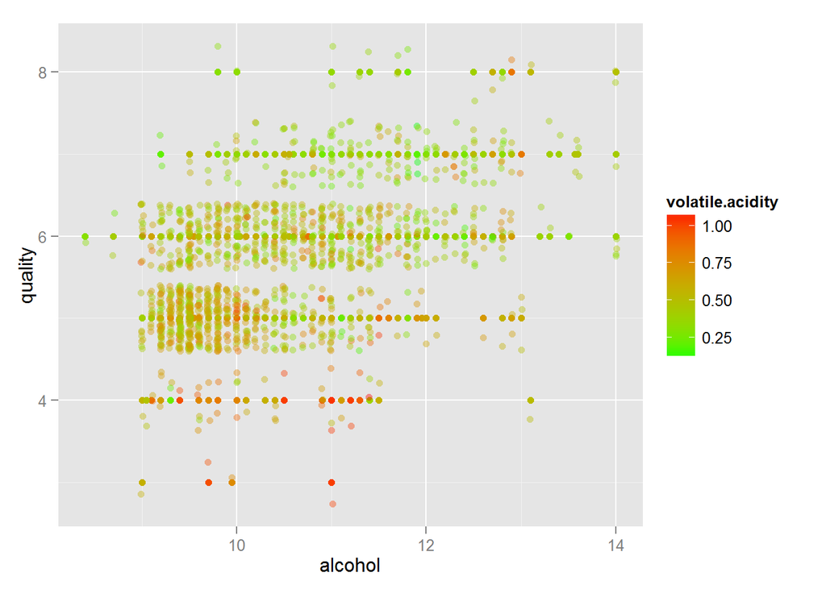

It’s pretty clear that wine quality goes higher with lower volatile acidity when holding alcohol constant.

Let’s explore some other scatter plots, continuously using alcohol to be points’ x axis, quality the y axis and other features the color.

Plot using sulphates as color.

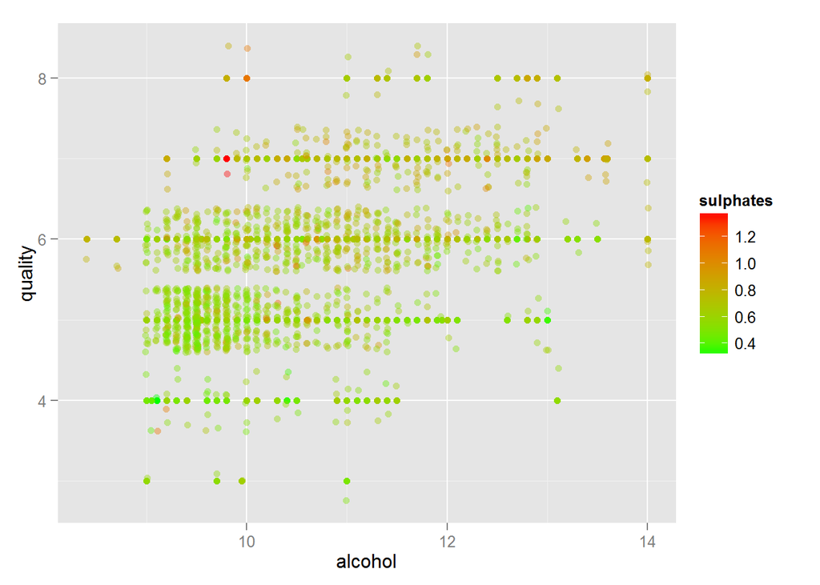

It shows when alchol keeps constant, higher sulphates means higher quality.

Plot using fixed acidity as color.

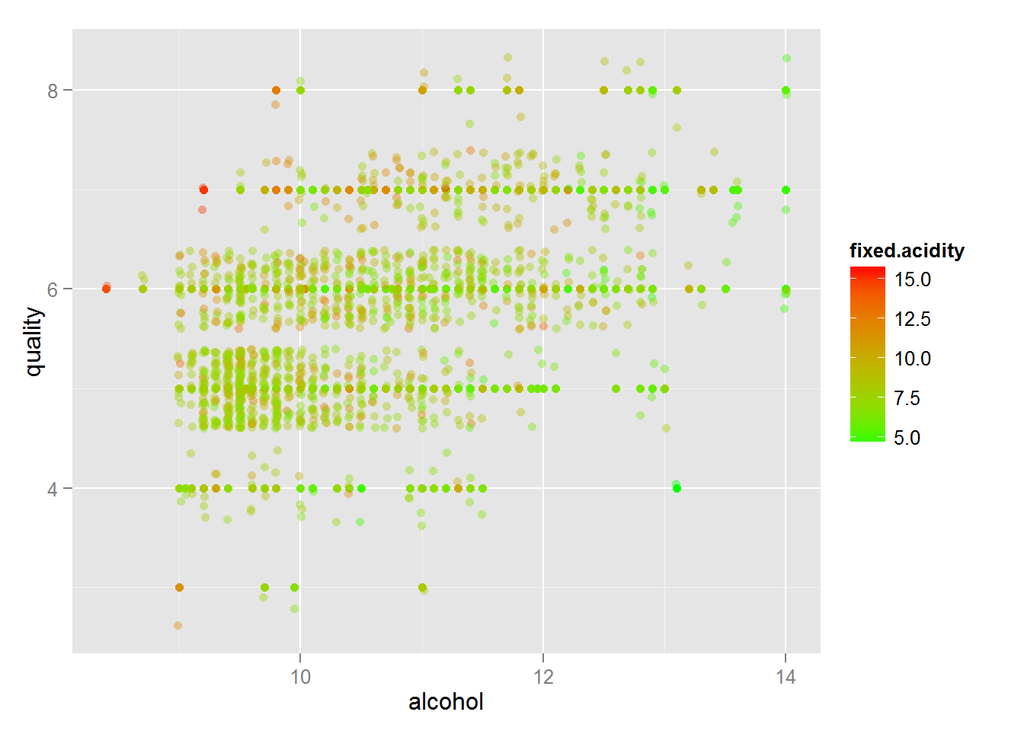

This plot is vaguely shows that when holding alcohol constant, higher fixed acidity seems to bring higher quality.

Plot using density as color.

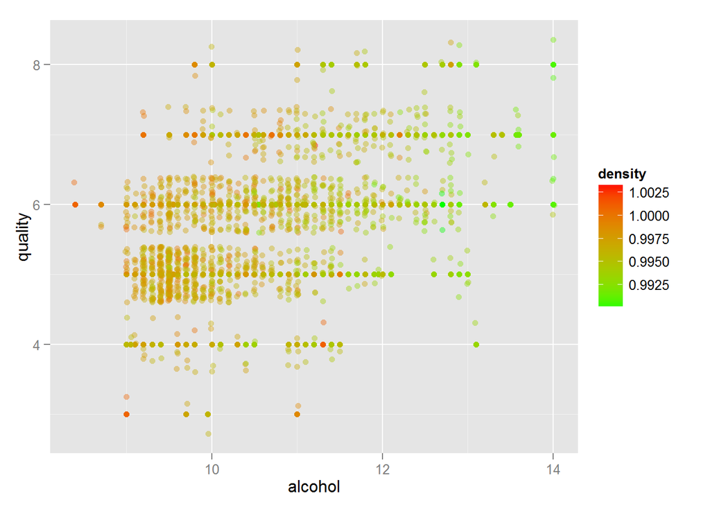

This plot is not clear what’s the correlation between density and quality.

Plot using citric acid as color.

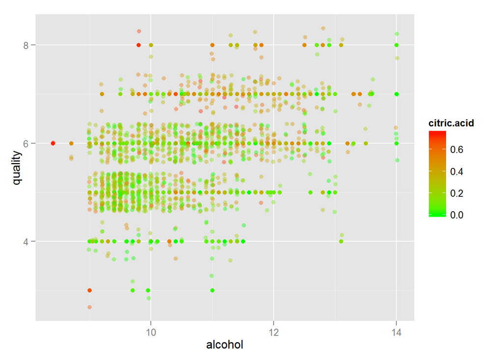

This plot is clear. When holding alcohol constant, higher citric acid means higher quality.

Plot using chlorides as color.

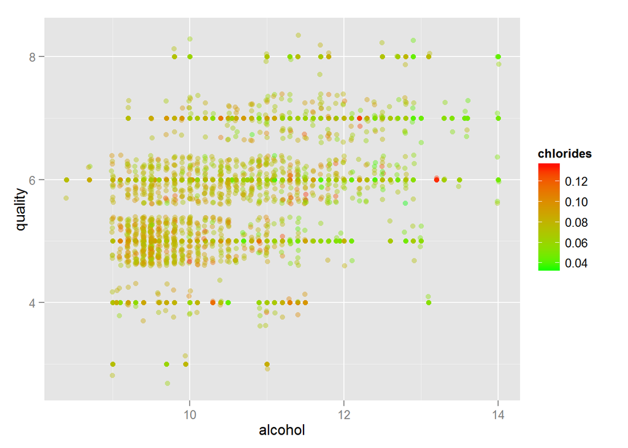

From the above colored plot, it seems when chlorides decreases, quality increases with alcohol constant.

Plot using total sulfur dioxide as color.

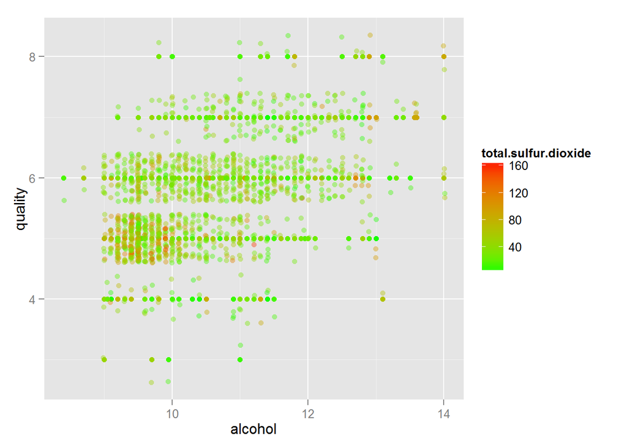

From the above color plot, it seems higher total sulfur dioxide brings lower quality when holding alcohol constant.

Density is the another feature of my interest. As I mentioned above, density seems to be connected to fixed acidity and alcohol. I would like to see the scatter plot of density VS fixed acidity and alcohol.

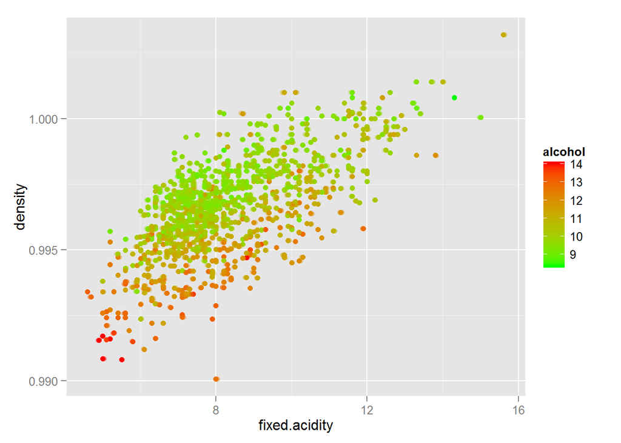

Yes, it’s obvious that there is negative corrleation between alcohol and density, positive correlation between fixed acidity and density.

I would like to build a linear model and use the other features to predict red wine quality. I know this set of data may not be very suitable to adapt linear model, but I’m curious what a linear model can tell us.

```
##
## Calls:
## m1: lm(formula = quality ~ 0 + alcohol, data = pf, offset = rep(5,
##     length(quality)))
## m2: lm(formula = quality ~ alcohol + sulphates - 1, data = pf, offset = rep(5,
##     length(quality)))
## m3: lm(formula = quality ~ alcohol + sulphates + volatile.acidity -
##     1, data = pf, offset = rep(5, length(quality)))
## m4: lm(formula = quality ~ alcohol + sulphates + volatile.acidity +
##     citric.acid - 1, data = pf, offset = rep(5, length(quality)))
## m5: lm(formula = quality ~ alcohol + sulphates + volatile.acidity +
##     citric.acid + total.sulfur.dioxide - 1, data = pf, offset = rep(5,
##     length(quality)))
## m6: lm(formula = quality ~ alcohol + sulphates + volatile.acidity +
##     citric.acid + total.sulfur.dioxide + density - 1, data = pf,
##     offset = rep(5, length(quality)))
## m7: lm(formula = quality ~ alcohol + sulphates + volatile.acidity +
##     citric.acid + total.sulfur.dioxide + density + chlorides -
##     1, data = pf, offset = rep(5, length(quality)))
## m8: lm(formula = quality ~ alcohol + sulphates + volatile.acidity +
##     citric.acid + total.sulfur.dioxide + density + chlorides +
##     fixed.acidity - 1, data = pf, offset = rep(5, length(quality)))
## m9: lm(formula = quality ~ alcohol + sulphates + volatile.acidity +
##     citric.acid + total.sulfur.dioxide + density + chlorides +
##     fixed.acidity + pH - 1, data = pf, offset = rep(5, length(quality)))
## m10: lm(formula = quality ~ alcohol + sulphates + volatile.acidity +
##     citric.acid + total.sulfur.dioxide + density + chlorides +
##     fixed.acidity + pH + free.sulfur.dioxide - 1, data = pf,
##     offset = rep(5, length(quality)))
## m11: lm(formula = quality ~ alcohol + sulphates + volatile.acidity +
##     citric.acid + total.sulfur.dioxide + density + chlorides +
##     fixed.acidity + pH + free.sulfur.dioxide + residual.sugar -
##     1, data = pf, offset = rep(5, length(quality)))
## m11: lm(formula = quality ~ alcohol + sulphates + volatile.acidity +
##     citric.acid + total.sulfur.dioxide + density + chlorides +
##     fixed.acidity + pH + free.sulfur.dioxide + residual.sugar -
##     1, data = pf, offset = rep(5, length(quality)))
##
## =============================================================================================================================================
##                          m1        m2        m3        m4        m5        m6        m7        m8        m9        m10       m11       m11
```

[output cut: 20 more lines]

```
##                                                                                                                 (0.002)   (0.002)   (0.002)
## residual.sugar                                                                                                            -0.015    -0.015
##                                                                                                                           (0.038)   (0.038)
## ---------------------------------------------------------------------------------------------------------------------------------------------
## R-squared                 0.983     0.983     0.987     0.987     0.987     0.988     0.988     0.988     0.989     0.989     0.989     0.989
## adj. R-squared            0.983     0.983     0.987     0.987     0.987     0.988     0.988     0.988     0.988     0.988     0.988     0.988
## sigma                     0.755     0.741     0.663     0.660     0.648     0.618     0.618     0.615     0.613     0.613     0.613     0.613
## F                     78494.425 40791.523 33913.259 25677.265 21255.443 19440.094 16669.552 14700.288 13153.147 11861.000 10776.037 10776.037
## p                         0.000     0.000     0.000     0.000     0.000     0.000     0.000     0.000     0.000     0.000     0.000     0.000
## Log-likelihood        -1573.553 -1547.571 -1393.093 -1385.766 -1361.486 -1294.173 -1293.407 -1287.557 -1282.566 -1280.731 -1280.658 -1280.658
## Deviance                787.432   758.415   606.677   600.287   579.590   525.867   525.285   520.863   517.120   515.751   515.696   515.696
## AIC                    3151.107  3101.142  2794.185  2781.533  2734.972  2602.346  2602.813  2593.113  2585.132  2583.462  2585.316  2585.316
## BIC                    3161.572  3116.840  2815.116  2807.696  2766.369  2638.975  2644.675  2640.208  2637.459  2641.022  2648.109  2648.109
## N                      1384      1384      1384      1384      1384      1384      1384      1384      1384      1384      1384      1384
## =============================================================================================================================================
```

From the statistics, we see that with alcohol, sulphates and volatile acidity, the R square value is already very close to the maximum. Adding more other feature does not promote the prediction very much.

# Multivariate Analysis

### Talk about some of the relationships you observed in this part of the investigation. Were there features that strengthened each other in terms of looking at your feature(s) of interest?

when exploring the correlation between alcohol and density, I found that when holding fixed acidity constant, higher alcohol leads to lower density.

### OPTIONAL: Did you create any models with your dataset? Discuss the strengths and limitations of your model.

I used linear model to predict quality. Although the prediction is good, I don’t think this models is 100% suitable to this case, since there are acturally very weak correlation between quality and other features. The high prediction accuracy probably mainly comes from the fact than quality values are very concentrative. Another thting is that the relation between quality and one other feature may not be linear. For example, the relation between quality and total sulfur dioxide is not linear. Linear model is not working well for such a case. I’m eager to learn the next course which is machine learning. That course should tell me how to predict the feature of interest better.

# Final Plots and Summary

My feature of main interest is quality. I want to show the correlation between quality and alcohol&sulphates. So the first two plots are “distribution of quality” and “scatter plot of quality VS alcohol and sulphates”. I’m also interested in what determines the density of red wine. So the last plot I chose is “scatter plot of density VS fixed acidity and alcohol”.

### Plot One: Check distribution of quality

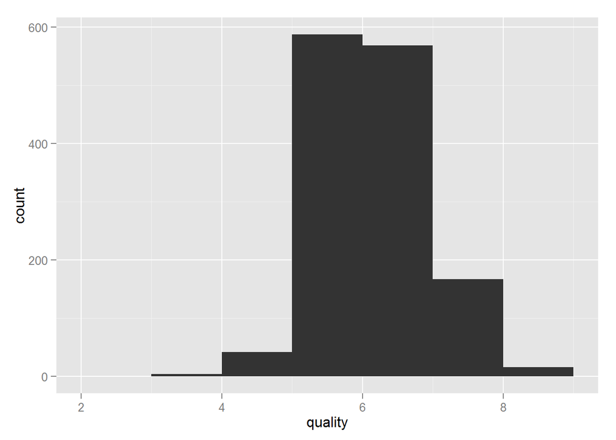

### Description One

Plot one is the distribution red wine quality. The minimum quality is 3 and the maximum is 8, although from the description features, quality’s range is from 0 to 10. Most of the quality values are 5 or 6, so the data is pretty concentrative.

### Plot Two: Correlation between alcohol and quality, sulphates and quality

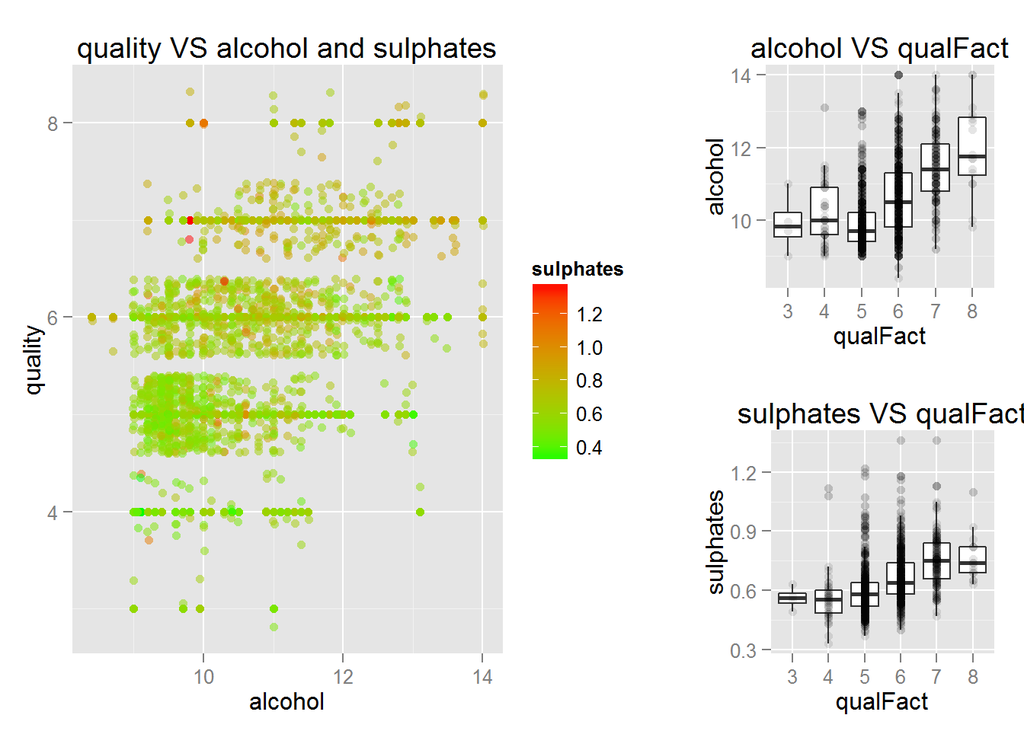

### Plot Three: Correlation between fixed acid and density, alcohol and density

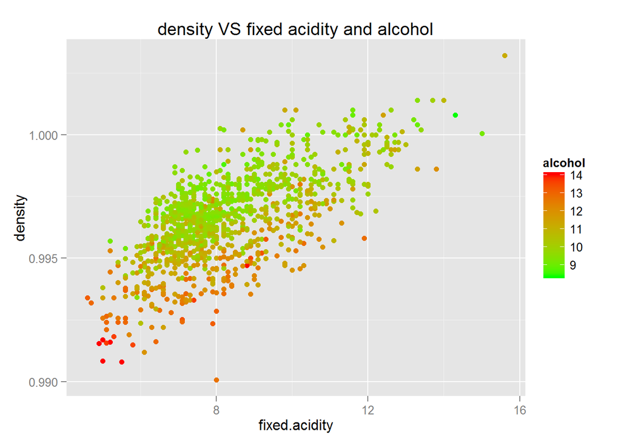

### Description Three

Fixed acidity and alcohol are the two most important features determing wine density. Wine with higher fixed acidity tends to have higher density. And higher alcohol makes the wine density smaller. This result could be easily explained. Alcohol has a lower density than water so it can make wine “lighter”. But the fixed acidity components have a larger density so that makes wine “heavier”.

# Reflection

Except for quality, which is the feature of main interest, I also explored which features may determine the density of wine. I found that fixed acidity and alcohol are the two most important features connecting to wine density. Alcohol has a lighter density while fixed acidity components have a heavier density. So wine with higher alcohol tends to have low density and wine with higher fixed acidity tends to have higher density.